# ADOC Facility Operations Analysis: 2010-2020

David Simpson

The below content offers an 11 year preliminary analysis of the Alabama Department of Corrections (ADOC)’s statistical reports on correctional facility operations for the years 2010-2020. All data used in this analysis are available in PDF format on ADOC’s statistical reports [webpage](http://www.doc.state.al.us/StatReports). Yearly values were sourced from the September monthly statistical report for each given year. September marks the end of ADOC’s reporting year. As such, the Facility Operations Table provides end of year (EOY) statistics for the past reporting year. A CSV file of the source data is posted on this GitHub [webpage](https://github.com/dcsimpson01/AL_prison_data).

## Facility Trends

Across all ADOC facilities, the total EOY incarcerated population has declined by 7,079 individuals (27.9%) from 25,395 in 2010 to 18,316 in 2020. Despite this decline, the total number of assaults and deaths per year have increased significantly. In 2020, the total number of reported assaults stood at 1,762 and represent a 321.5% increase over the 2010 total of 418. Similarly, the number of deaths increased from 77 to 150 (or 94.8%) during the period.

Prior to 2020, the most reported assaults occurred in 2018. The 2018 total was 2,132 assaults, a 410.0% increase over 2010. Despite a subsequent two year decline in the absolute number of assaults, there is little change in the number of assaults relative to the declining prison population. In 2018, the ratio of total assaults to the total prison population stood at 10.6, nearly 11 assaults for every 100 people. In 2020, the assault ratio stood at 9.6, nearly 10 for every 100 people.

In 2018, the death rate across all ADOC facilities stood at 0.7, or 7 deaths for every 1,000 people. In 2020, the rate is 0.8, or 8 deaths for every 1,000 people.

Total Population Statistics

| year | capacity | beds | pop | occupancy.rate | disciplinaries | assaults | assault.rate | deaths | death.rate |
| --- | --- | --- | --- | --- | --- | --- | --- | --- | --- |
| 2010 | 13,403 | 26,341 | 25,395 | 189.5 | 25,463 | 418 | 1.6 | 77 | 0.3 |
| 2011 | 13,403 | 26,339 | 25,668 | 191.5 | 23,942 | 849 | 3.3 | 107 | 0.4 |
| 2012 | 13,403 | 26,067 | 25,374 | 189.3 | 29,342 | 875 | 3.4 | 89 | 0.4 |
| 2013 | 13,318 | 26,145 | 25,340 | 190.3 | 28,439 | 967 | 3.8 | 104 | 0.4 |
| 2014 | 13,318 | 26,143 | 24,816 | 186.3 | 28,733 | 1,265 | 5.1 | 111 | 0.4 |
| 2015 | 13,318 | 25,763 | 24,191 | 181.6 | 27,075 | 1,362 | 5.6 | 124 | 0.5 |
| 2016 | 13,318 | 25,784 | 23,328 | 175.2 | 24,350 | 1,764 | 7.6 | 100 | 0.4 |
| 2017 | 13,318 | 25,784 | 21,213 | 159.3 | 21,489 | 1,767 | 8.3 | 120 | 0.6 |
| 2018 | 13,318 | 22,309 | 20,087 | 150.8 | 22,052 | 2,132 | 10.6 | 136 | 0.7 |
| 2019 | 12,412 | 22,231 | 20,953 | 168.8 | 19,956 | 1,898 | 9.1 | 119 | 0.6 |
| 2020 | 12,412 | 22,690 | 18,316 | 147.6 | 17,594 | 1,762 | 9.6 | 150 | 0.8 |

<sup>a</sup> Occupancy Rate = (Population / Capacity) x 100  
<sup>b</sup> Assault Rate = (Assaults / Population) x 100  
<sup>c</sup> Death Rate = (Deaths / Population) x 100  
<sup>d</sup> Deaths include homicides, suicides, executions, and natural causes (ADOC Sept. 2018 Report, p.10).

In 2020, Medium Security facilities held 9,485 individuals (52% of all ADOC inmates). These facilities accounted for 1,041 assaults (59% of all assaults) and 57 deaths (38% of all deaths). The assault rate across all Medium Security facilities was 11 (11 assaults for every 100 people). The death rate was 0.6 (6 for every 1,000 people).

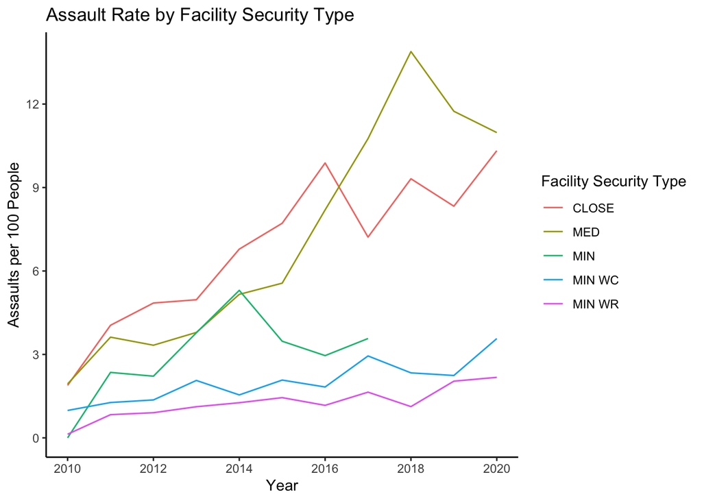

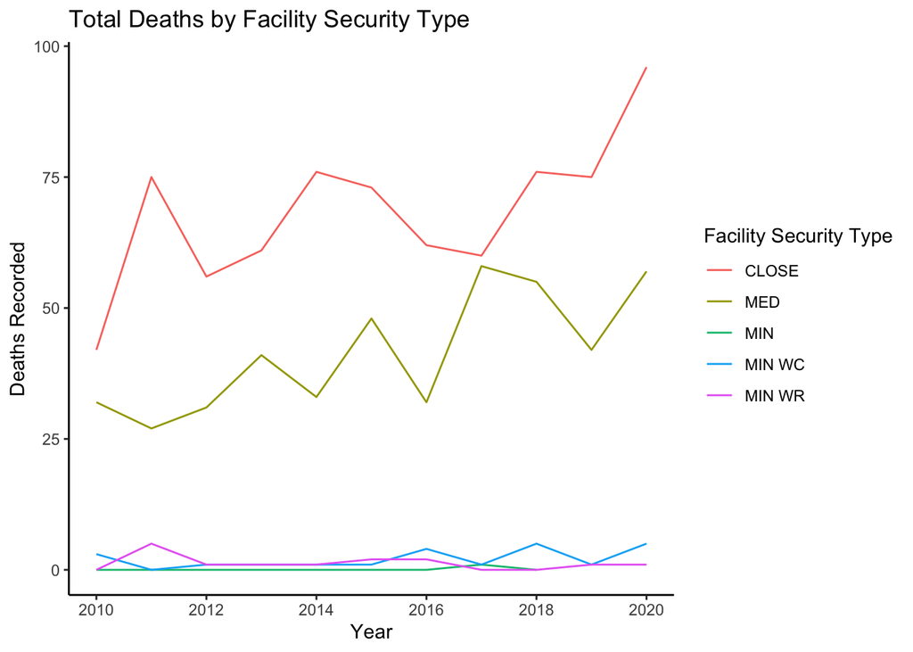

## Assaults in Close and Medium Security Facilities

Within the Close Security category, assaults are not confined to just one facility. With the exception of Holman (which had the highest assault rate in 2019 and has since had had its population reduced by nearly 80%), all Close Security facilities recorded well over 50 assaults in 2020. Among male prisons, Donaldson recorded the most assaults (191) and Kilby recorded the highest assault rate (15 for every 100 people). Tutwiler is the only Close Security female prison. The assault rate at Tutwiler was over 21 for every 100 people.

2020 Close Security Facilities: Assault Statistics

| facility | type | assaults | pop | assault.rate |
| --- | --- | --- | --- | --- |
| DONALDSON | MALE | 191 | 1492 | 12.8 |
| HOLMAN | MALE | 9 | 147 | 6.1 |
| KILBY | MALE | 155 | 1031 | 15.0 |
| LIMESTONE | MALE | 88 | 2067 | 4.3 |
| ST. CLAIR | MALE | 102 | 1097 | 9.3 |
| TUTWILER | FEMALE | 104 | 484 | 21.5 |

Within the Medium Security category, assaults are also not confined to just one facility. In 2020, every Medium Security facility with a population over 1,000 people recorded over 100 assaults. The assault rate at those facilities either approaches or exceeds 10.0 (1 assault for every 10 people). Ventress had both the most assaults (191) and the highest assault rate (18.5). Such a rate is almost (1 assault for every 5 people). The lowest number of assaults occurred in the Hamilton, Montgomery and Tutwiler Annex faculties. Each of these facilities also have the smallest population total among the Medium Security facilities.

2020 Medium Security Facilities: Assault Statistics

| facility | type | assaults | pop | assault.rate |
| --- | --- | --- | --- | --- |
| BIBB | MALE | 150 | 1696 | 8.8 |
| BULLOCK | MALE | 185 | 1490 | 12.4 |
| EASTERLING | MALE | 126 | 1162 | 10.8 |
| ELMORE | MALE | 101 | 1104 | 9.1 |
| FOUNTAIN | MALE | 124 | 1142 | 10.9 |
| HAMILTON A/I | MALE | 6 | 256 | 2.3 |
| MONTGOMERY | FEMALE | 10 | 159 | 6.3 |
| STATON | MALE | 140 | 1316 | 10.6 |
| TUTWILER ANNEX | FEMALE | 8 | 127 | 6.3 |
| VENTRESS | MALE | 191 | 1033 | 18.5 |

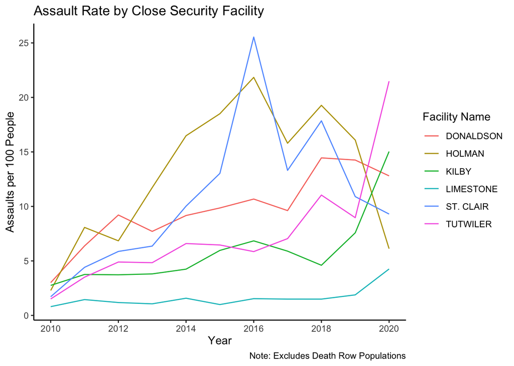

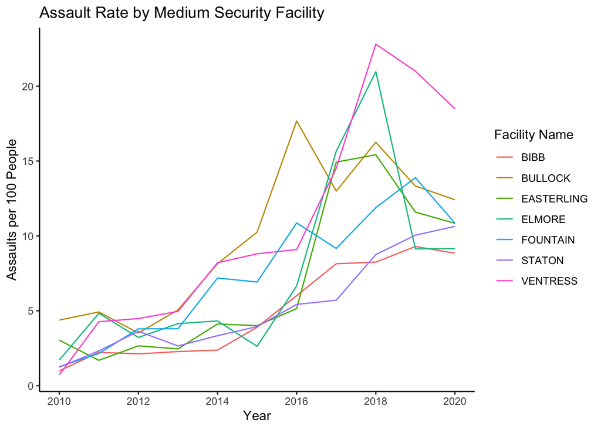

## Concluding Remarks

The above analysis provides a preliminary assessment of population changes, assaults, and deaths within ADOC’s facilities. It is clear that the number of assaults and deaths within ADOC’s facilities have risen dramatically and are concentrated in the Close and Medium Security facilities. The increase is especially concerning in the context of Close and Medium Security population trends. Even though such facilities have experienced an overall population decline since 2010, the facilities have also experienced a dramatic increase in the total number of recorded assaults and deaths.

It is important to note that the above numbers represent values aggregated across security facility type. As such, the numbers represent an initial overview of horrific trends within ADOC facilities; however, by themselves, they do not identify the specific root causes for these trends. Even so, the dramatic increase in assaults and deaths strongly underscores the necessity for recent actions taken by the United States Department of Justice. On April 2, 2019 the DOJ released an investigatory [report](https://www.justice.gov/opa/press-release/file/1150276/download) which concluded that “there is reasonable cause to believe that conditions at Alabama’s prisons violate the Eighth Amendment to the Constitution.” On December 9, 2020, the DOJ [sued](https://www.justice.gov/opa/press-release/file/1344011/download) Alabama in order to enforce both the Eighth and Fourteenth Amendment rights of men in Alabama prisons. The suit lays out many specific and horrifying allegations of how the state has failed to “prevent prisoner-on-prisoner violence and sexual abuse,” and “failed to protect prisoners from the use of excessive force by security staff” (p. 1). The DOJ also alleges that Alabama is “deliberately indifferent to the serious and systemic constitutional problems present in Alabama’s prisons” (p. 2-3).

For individuals wishing to gain a more nuanced depiction of disciplinary events, assaults, and deaths, one should consult the September monthly reports for each of the years included in this analysis. Consulting tables such as the *Disciplines, Assaults, Homicides, Deaths, and Suicides* table can contextualize disciplinary events by sub-category (major and minor), and assaults by injury classification and number of victims. Furthermore, such tables can provide insight on variables not analyzed here in this document (Note, in 2019 this table was renamed the *Disciplines, Assaults, Fighting, Deaths, and Suicides* table). For example, the September 2020 publication of that table indicates that 6 individuals died by suicide in Close and Medium Security Facilities in 2020. Another 70 suicides were attempted in such facilities during the 2020 reporting year.

Unfortunately, since Alabama does not follow industry standard open data practices, more time is needed to scrape and clean PDF data documents so that these important topics can be analyzed in more detail. Though, even if Alabama released its current statistical reports in a CSV format, there is reason to believe they are incomplete, misreported, or falsified. For example, the DOJ alleges that ADOC does not “accurately classify the causes of death within Alabama’s prisons,” that it has classified deaths caused by prisoner-on-prisoner violence as death occurring by natural causes, and it “does not have a centralized system to track or review prisoner mortalities” (p. 9). Furthermore, the statistical reports provide no insight on instance of sexual abuse and rape. However even if such data were reported, it is unlikely to be accurate. The DOJ alleges that ADOC not only fails to prevent sexual abuse, it “fails to conduct adequate investigations of sexual abuse,” dismisses alleged sexual abuse as consensual sex, disregards abuse that is “the result of a drug debt” and frequently discourages the reporting of sexual abuse (p. 8-9).

Finally, it is important to note that ADOC’s statistical reports provide no clear incident records on use of force by security staff. For the best insight on this topic, one should again consult the DOJ lawsuit. The document alleges that multiple individuals have “died as a result of use of force by security staff,” that security staff fail to “document or report uses of force to supervisors,” and “have a practice of falsifying incident documents related to uses of force” (p. 15).

# Appendix

## Appendix Section 1: Plots by Facility Security Type

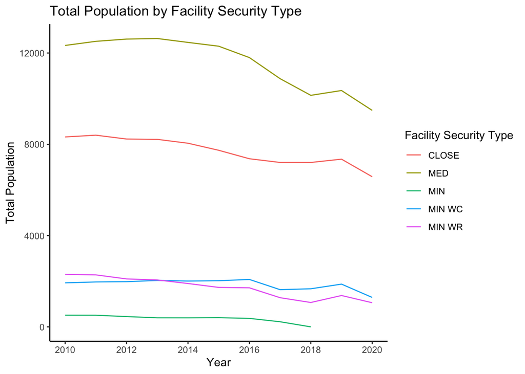

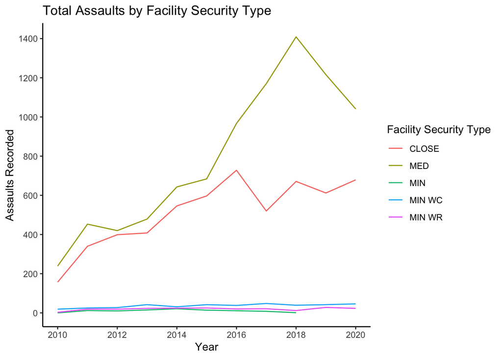

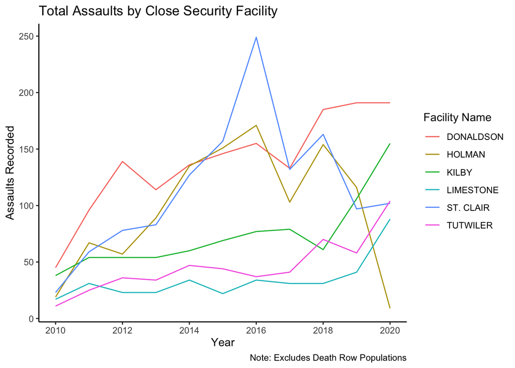

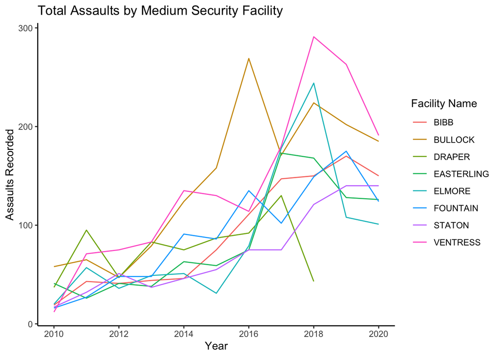